# HW3

Group A4 24

6 June 2024

- Lior Belkin, 315818765, lior.belkin@mail.huji.ac.il
- Narmeen Shwiki, 322764895, narmeen.shwiki@mail.huji.ac.il
- Yael Mendelsohn ,345459754. yael.mendelsohn@mail.huji.ac.il

### Libraries used

```r
library(data.table)
library(splines)
library(ggplot2)
library(scales)
library(dplyr)
library(openxlsx)
```

## Loading the data

```r
#loading the data
load("reads_gc_5K.rda")
```

```r
if(any(GC_5K>1)){
  GC_5K = GC_5K / 5000
}
```

# Step 2: cleaning the data (removing outliers)

First, let’s try to visualize our data. We do this with the scatter-plot below. Each data-point represents one of the 49,440 bins. Clearly we have to remove outliers in order to be able to properly visualize our data.

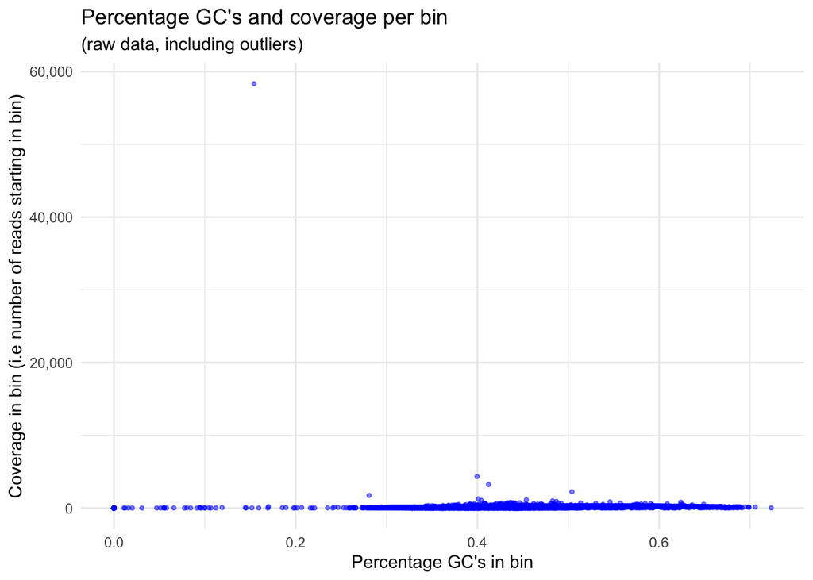

```r
ggplot(data.frame(GC_5K = GC_5K, reads_5K = reads_5K),
            aes(x = GC_5K, y = reads_5K)) +
  geom_point(shape = 20, alpha = 0.5, color = "blue") +
  labs(
    title = "Percentage GC's and coverage per bin",
    subtitle="(raw data, including outliers)",
    x = "Percentage GC's in bin",
    y = "Coverage in bin (i.e number of reads starting in bin)"
  )+
  scale_y_continuous(labels=comma)+
  theme_minimal()
```

1. We remove the bins and in which the percentage GC’s is 0% Reason: we think there’s a mistake in the data, how could it be possible that among the 5000 bases there is not even one which is C or G? We don’t want to use these bins.

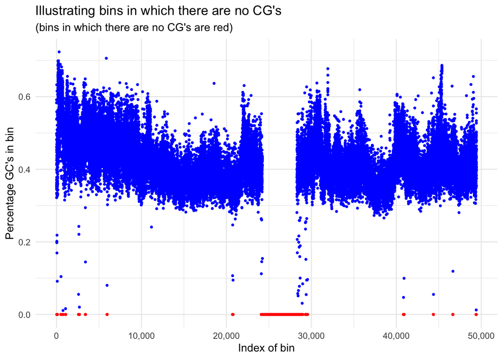

```r
ggplot(data.frame(GC_5K,
                  index_of_bin=seq_along(GC_5K),
                  color=ifelse(GC_5K!=0,"blue","red")),
       aes(x=index_of_bin,
           y=GC_5K,
           color=color)
       )+
  geom_point(size=0.7)+
  scale_color_identity()+
  labs(title="Illustrating bins in which there are no CG's",
       subtitle="(bins in which there are no CG's are red)",
       x="Index of bin",
       y="Percentage GC's in bin")+
  scale_x_continuous(labels=comma)+
  theme_minimal()
```

```r
indices_GC_5K_is_zero<-which(GC_5K==0)
GC_5K_clean<-GC_5K[-indices_GC_5K_is_zero]
reads_5K_clean<-reads_5K[-indices_GC_5K_is_zero]
```

2. We exclude bins where the number of reads exceeds the 99.9th percentile threshold. Reason: we want to focus our analysis on typical bins, not outliers. Also, we’ll be able to better visualize the data.

```r
quantile_999<-quantile(reads_5K_clean,0.999)
quantile_999
```

```
##   99.9%
## 558.852
```

```r
indices_reads_5K_is_above_Q999<-which(reads_5K_clean>quantile_999)

GC_5K_clean<-GC_5K_clean[-indices_reads_5K_is_above_Q999]
reads_5K_clean<-reads_5K_clean[-indices_reads_5K_is_above_Q999]
```

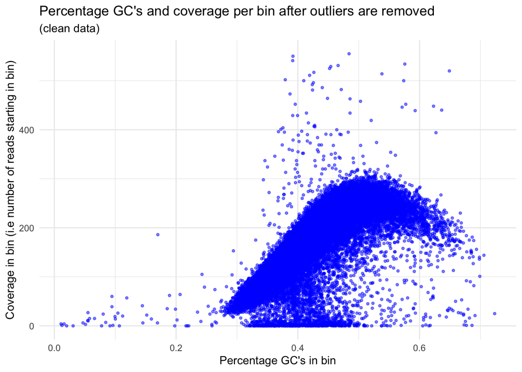

```r
ggplot(data.frame(GC_5K_clean = GC_5K_clean, reads_5K_clean = reads_5K_clean),
            aes(x = GC_5K_clean, y = reads_5K_clean)) +
  geom_point(shape = 20, alpha = 0.5, color = "blue") +
  labs(
    title = "Percentage GC's and coverage per bin after outliers are removed",
    subtitle="(clean data)",
    x = "Percentage GC's in bin",
    y = "Coverage in bin (i.e number of reads starting in bin)"
  )+
  scale_y_continuous(labels=comma)+
  theme_minimal()
```

# Step 3: performing piecewise/spline polynomial regression

```r
# Set knots based on data characteristics
knots <- c(0.26, 0.53)

# Fit the polynomial regression model
degree <- 3
poly_fit <- lm(reads_5K_clean ~ bs(GC_5K_clean, knots = knots, degree = degree))

# Generate a sequence of GC content for predictions
GC_5K_seq <- seq(min(GC_5K_clean), max(GC_5K_clean), length.out = 100)

# Create the design matrix for the sequence using the same basis function
design_matrix_seq <- bs(GC_5K_seq, knots = knots, degree = degree)

# Predict using the polynomial model
predicted_poly <- predict(poly_fit, newdata = data.frame(GC_5K_clean = GC_5K_seq))
```

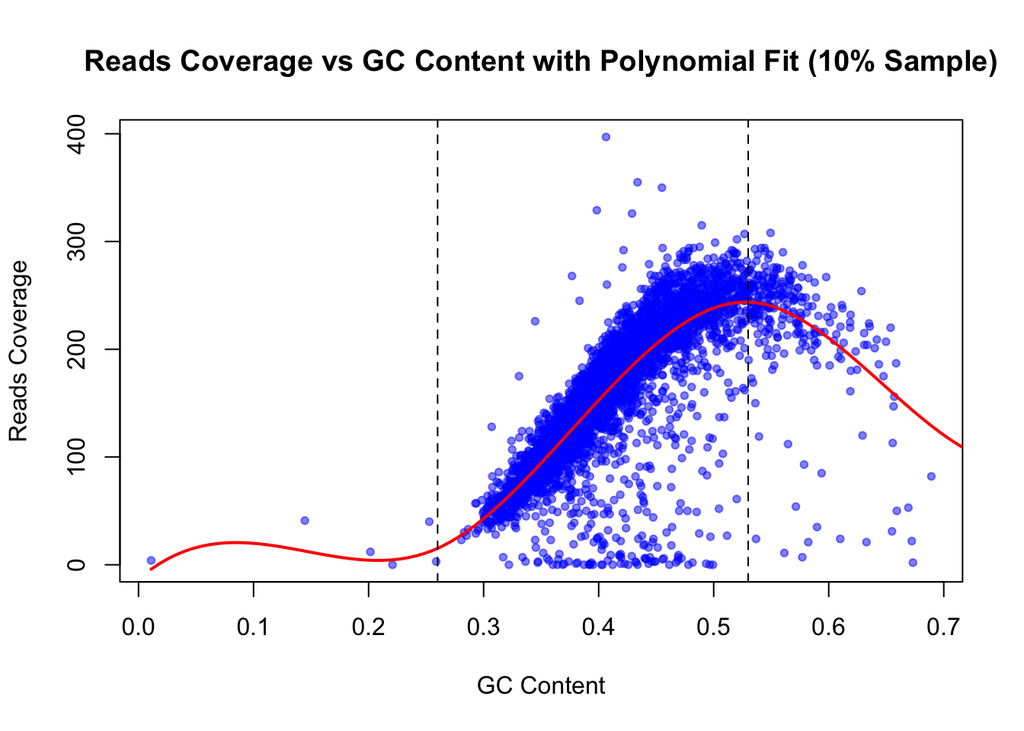

```r
# Sample 10% of the data points
set.seed(100)
sample_indices <- sample(length(GC_5K_clean), size = 0.1 * length(GC_5K_clean))

# Plot the sampled data points
plot(GC_5K_clean[sample_indices], reads_5K_clean[sample_indices],
     main = "Reads Coverage vs GC Content with Polynomial Fit (10% Sample)",
     xlab = "GC Content", ylab = "Reads Coverage", pch = 20, col = rgb(0, 0, 1, alpha = 0.5))

# Add the polynomial regression line to the plot
lines(GC_5K_seq, predicted_poly, col = "red", lwd = 2)

# Add dashed lines for knots
for (i in knots) {
  abline(v = i, col = "black", lty = 2)
}
```

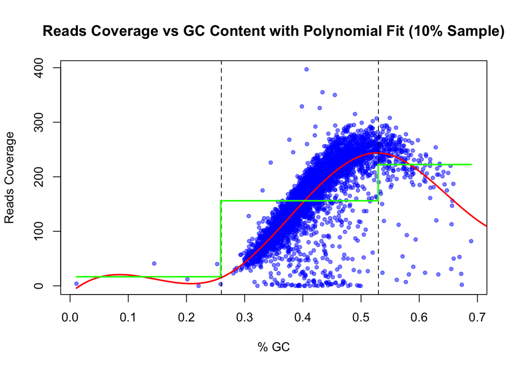

```r
regions <- cut(GC_5K_clean[sample_indices], breaks = c(-Inf, knots, Inf))

# Function to plot piecewise constant functions for each region
plot_piecewise_constant <- function(x, y, regions, knots) {
  # Sort x, y, and regions based on x
  order_index <- order(x)
  x <- x[order_index]
  y <- y[order_index]
  regions <- regions[order_index]
  unique_regions <- sort(unique(regions))

  for (i in seq_along(unique_regions)) {
    region_label <- unique_regions[i]
    x_region <- x[regions == region_label]
    y_region <- y[regions == region_label]

    # Calculate the mean for the current region
    mean_y <- mean(y_region)

    # Draw the horizontal line for the current region
    lines(c(min(x_region), max(x_region)), c(mean_y, mean_y), col = "green", lwd = 2)

    # Draw vertical line connecting to the next segment
    if (i < length(unique_regions)) {
      # Next region's boundary and mean
      next_region_label <- unique_regions[i + 1]
      x_next_region <- x[regions == next_region_label]
      mean_next_y <- mean(y[regions == next_region_label])

      # The boundary x-value where we want the vertical line to be drawn
      boundary_x <- max(x_region)

      # Draw the vertical line exactly at the boundary between segments
      lines(c(boundary_x, boundary_x), c(mean_y, mean_next_y), col = "green", lwd = 2)

      # Ensure there is no gap by extending the horizontal line of the next segment from boundary_x
      lines(c(boundary_x, max(x_next_region)), c(mean_next_y, mean_next_y), col = "green", lwd = 2)
    }
  }
}

plot(GC_5K_clean[sample_indices], reads_5K_clean[sample_indices],
     main = "Reads Coverage vs GC Content with Polynomial Fit (10% Sample)",
     xlab = "% GC", ylab = "Reads Coverage", pch = 20, col = rgb(0, 0, 1, alpha = 0.5))
lines(GC_5K_seq, predicted_poly, col = "red", lwd = 2)
for (i in knots) {
  abline(v = i, col = "black", lty = 2)
}
# plot piecewise constant functions on the sampled data
plot_piecewise_constant(GC_5K_clean[sample_indices], reads_5K_clean[sample_indices], regions, knots)
```

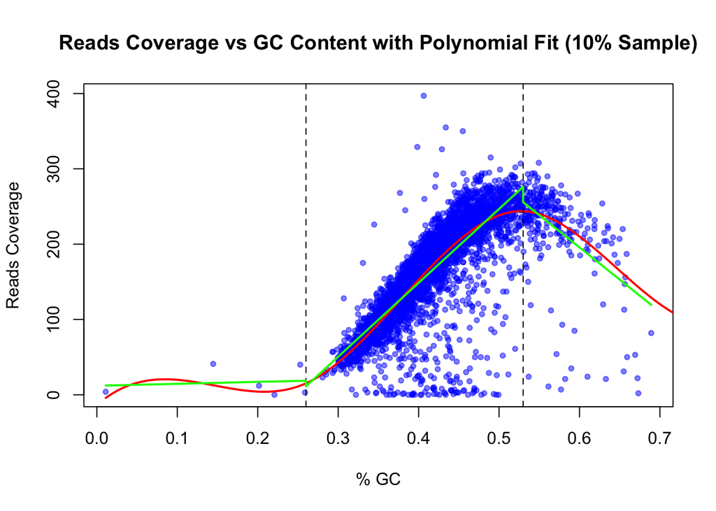

```r
# Function to plot piecewise linear functions for each region
plot_piecewise_linear <- function(x, y, knots) {
  # Sort x and y based on x
  order_index <- order(x)
  x <- x[order_index]
  y <- y[order_index]

  # Add knots to the boundaries of the data
  knots <- c(min(x), knots, max(x))

  # Initialize variables to store the previous end point
  prev_end_x <- NA
  prev_end_y <- NA

  # Loop over each segment defined by the knots
  for (i in 1:(length(knots) - 1)) {
    start_knot <- knots[i]
    end_knot <- knots[i + 1]

    # Get data within the current segment
    segment_index <- which(x >= start_knot & x <= end_knot)
    x_segment <- x[segment_index]
    y_segment <- y[segment_index]

    # Fit a linear model for the current segment
    lm_segment <- lm(y_segment ~ x_segment)

    # Create a sequence of x values for a smooth line
    x_pred <- seq(start_knot, end_knot, length.out = 100)
    # Predict y values using the linear model
    y_pred <- predict(lm_segment, newdata = data.frame(x_segment = x_pred))

    # Plot the linear segment
    lines(x_pred, y_pred, col = "green", lwd = 2)

    # If there's a previous segment, connect to the current one with a vertical line at the start_knot
    if (!is.na(prev_end_x)) {
      # Draw a vertical line connecting the segments
      lines(c(prev_end_x, start_knot), c(prev_end_y, y_pred[1]), col = "green", lwd = 2)
    }

    # Update previous end point to the current segment's end
    prev_end_x <- end_knot
    prev_end_y <- y_pred[length(y_pred)]
  }
}

plot(GC_5K_clean[sample_indices], reads_5K_clean[sample_indices],
     main = "Reads Coverage vs GC Content with Polynomial Fit (10% Sample)",
     xlab = "% GC", ylab = "Reads Coverage", pch = 20, col = rgb(0, 0, 1, alpha = 0.5))
lines(GC_5K_seq, predicted_poly, col = "red", lwd = 2)
for (i in knots) {
  abline(v = i, col = "black", lty = 2)
}

# Call the function to plot piecewise linear functions on the sampled data
plot_piecewise_linear(GC_5K_clean[sample_indices], reads_5K_clean[sample_indices], knots)
```

# Question B

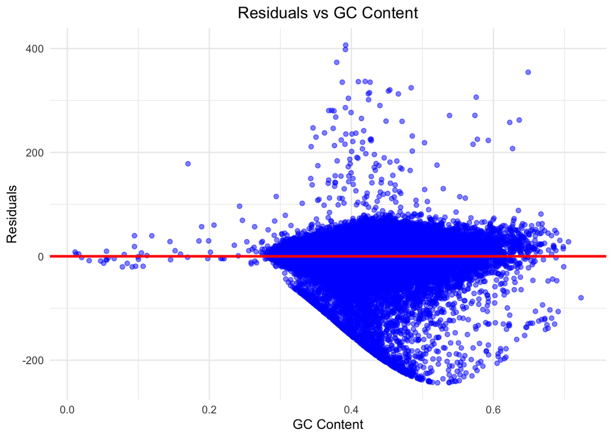

```r
predicted_reads <- predict(poly_fit, newdata = data.frame(GC_5K_clean = GC_5K_clean))

# Calculate the residuals
residuals <- reads_5K_clean - predicted_reads

# Create data frame for residuals
residuals_data <- data.frame(GC_5K_clean = GC_5K_clean, residuals = residuals)

# Plot the residuals against GC content with alpha = 0.5
residuals_plot <- ggplot(residuals_data, aes(x = GC_5K_clean, y = residuals)) +
  geom_point(color = 'blue', alpha = 0.5) +
  geom_hline(yintercept = 0, color = 'red', linetype = 'solid', linewidth = 1) +
  labs(title = "Residuals vs GC Content",
       x = "GC Content",
       y = "Residuals") +
  theme_minimal() +
  theme(plot.title = element_text(hjust = 0.5))
print(residuals_plot)
```

# Question C: finding a numerical measure to compare the linear model to our piecewise polynomial model

```r
# Fit a linear model to the data
linear_model <- lm(reads_5K_clean ~ GC_5K_clean)

# Calculate predictions from the linear model
linear_predictions <- predict(linear_model, newdata = data.frame(GC_5K_clean = GC_5K_clean))

# Use the existing polynomial spline model to get predictions
spline_predictions <- predict(poly_fit, newdata = data.frame(GC_5K_clean = GC_5K_clean))

# Calculate MSE for the polynomial spline model
spline_mse <- mean((reads_5K_clean - spline_predictions)^2)

# Calculate MSE for the linear model
linear_mse <- mean((reads_5K_clean - linear_predictions)^2)

# Calculate the improvement ratio
improvement_ratio <- linear_mse / spline_mse

# Print the results
cat("MSE of Polynomial Spline model:", spline_mse, "\n")
```

```
## MSE of Polynomial Spline model: 1427.42
```

```r
cat("MSE of Linear model:", linear_mse, "\n")
```

```
## MSE of Linear model: 1879.666
```

```r
cat("Improvement in fit (Linear MSE / Spline MSE):", improvement_ratio, "\n")
```

```
## Improvement in fit (Linear MSE / Spline MSE): 1.316827
```

# Question D: Analysing the residuals

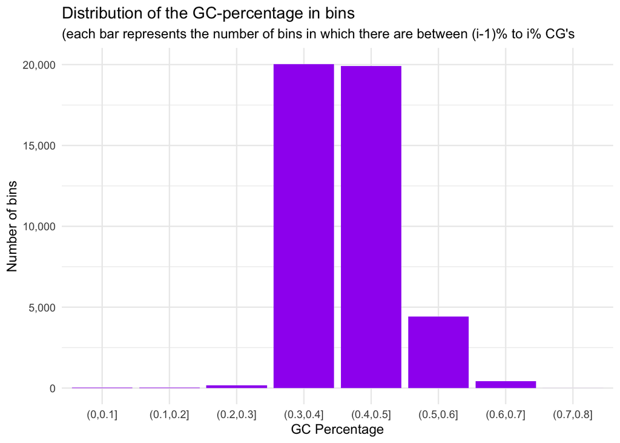

```r
# Calculate the residuals
spline_predictions <- predict(poly_fit, newdata = data.frame(GC_5K_clean = GC_5K_clean))
residuals <- reads_5K_clean - spline_predictions

database_residuals<-data.frame(residuals=residuals,
                               GC_5K_clean=GC_5K_clean)

breaks_GC_percentage<-seq(0,1,by=0.1)

database_residuals<-database_residuals%>%
  mutate(GC_percentage=cut(GC_5K_clean,breaks=breaks_GC_percentage))

# Create barplot
ggplot(data.frame(database_residuals%>%group_by(GC_percentage)%>%summarize(count_bins=n())),
       aes(x=GC_percentage,
           y=count_bins))+
  geom_bar(stat="identity",fill="purple")+
  labs(title="Distribution of the GC-percentage in bins",
       subtitle="(each bar represents the number of bins in which there are between (i-1)% to i% CG's",
       x="GC Percentage",
       y="Number of bins")+
  scale_y_continuous(labels=comma)+
  theme_minimal()
```

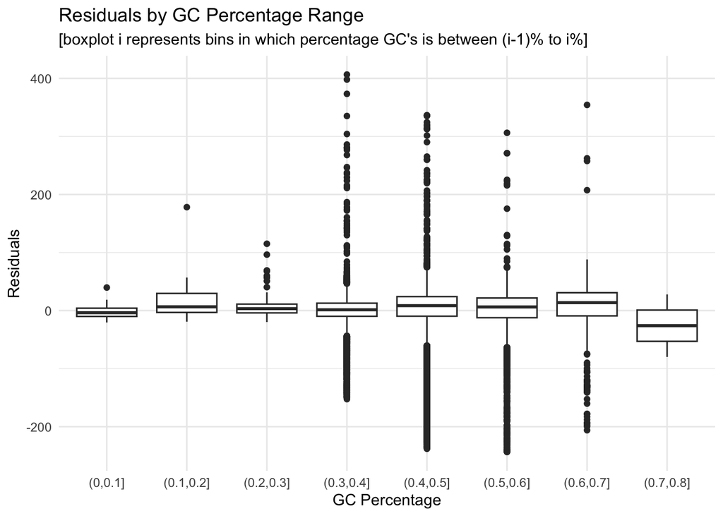

```r
# Create boxplot
ggplot(database_residuals, aes(x = GC_percentage, y = residuals)) +
  geom_boxplot() +
  labs(title = "Residuals by GC Percentage Range",
       subtitle="[boxplot i represents bins in which percentage GC's is between (i-1)% to i%]",
       x = "GC Percentage",
       y = "Residuals") +
  theme_minimal()
```

```r
statistic_residuals<-database_residuals%>%group_by(GC_percentage)%>%
  summarize(count_bins=n(),
            mean(residuals),
            sd(residuals),
            Q1_residuals=quantile(residuals,0.25),
            Q3_residuals=quantile(residuals,0.75),
            IQR=Q3_residuals-Q1_residuals,
            Lower_outlier_bound=Q1_residuals-1.5*IQR,
            Upper_outlier_bound=Q3_residuals+1.5*IQR,
            count_outlier_bins=sum(ifelse(residuals<Lower_outlier_bound | residuals>Upper_outlier_bound, 1, 0)),
            percentage_outliers=count_outlier_bins/n()
            )

create_statistic_residuals<-FALSE
  if(create_statistic_residuals){
    write.xlsx(statistic_residuals,"statistic_residuals.xlsx")
  }


statistic_residuals
```

```
## # A tibble: 8 × 11
##   GC_per…¹ count…² mean(…³ sd(re…⁴ Q1_re…⁵ Q3_re…⁶   IQR Lower…⁷ Upper…⁸ count…⁹
##   <fct>      <int>   <dbl>   <dbl>   <dbl>   <dbl> <dbl>   <dbl>   <dbl>   <dbl>
## 1 (0,0.1]       20  -2.01     14.3  -10.1    4.19   14.3   -31.5    25.6       1
## 2 (0.1,0.…      15  23.2      47.6   -3.13  29.6    32.7   -52.2    78.7       1
## 3 (0.2,0.…     158   6.53     18.3   -3.93  11.1    15.1   -26.5    33.7       8
## 4 (0.3,0.…   20036  -0.538    26.3   -9.80  12.8    22.6   -43.7    46.7     988
## 5 (0.4,0.…   19919   0.533    45.2   -9.66  24.1    33.7   -60.2    74.6    1433
## 6 (0.5,0.…    4418  -0.485    42.9  -12.2   21.7    34.0   -63.2    72.7     264
## 7 (0.6,0.…     424   2.38     58.8   -9.16  30.8    40.0   -69.1    90.7      44
## 8 (0.7,0.…       2 -26.0      76.2  -52.9    0.971  53.9  -134.     81.8       0
## # … with 1 more variable: percentage_outliers <dbl>, and abbreviated variable
## #   names ¹GC_percentage, ²count_bins, ³`mean(residuals)`, ⁴`sd(residuals)`,
## #   ⁵Q1_residuals, ⁶Q3_residuals, ⁷Lower_outlier_bound, ⁸Upper_outlier_bound,
## #   ⁹count_outlier_bins
```